# TRABAJO FIN DE MÁSTER: DETECCIÓN TEMPRANA DE SEPSIS

**Autor:** Jesús Guerrero Quirós

**Tutores del trabajo:** Juan Antonio Nepomuceno Chamorro y Juan Antonio Nepomuceno Chamorro

**Titulación:** Máster Oficial en Ingeniería Biomédica y Salud Digital

**Centro:** Escuela Técnica Superior de Ingeniería Informática

Universidad de Sevilla | Curso 2022/2023

# **VARIABLE: SOFA**

En este notebook se llevará a cabo el estudio de la variable objetivo *SOFA*. Esta variable consiste en un sistema de medición de fallo orgánico múltiple. Para ello, se analizan 6 posibles disfunciones: respiración, coagulación, hígado, cardiovascular, sistema nervioso central y renal.

Cada una de esas disfunciones adquiere una puntuación de 0 (normal) a 4 (anormal), y la puntuación final es la suma de los puntos obtenidos por todas las posibles disfunciones. De esta manera, la puntuación final será un valor entre 0 y 24.

Es un sistema de predicción muy útil, ya que permite predecir la tasa de mortalidad del paciente. Por ejemplo, un aumento en la puntuación SOFA durante las primeras 48 horas en la UCI se traduce en una tasa de mortalidad del 50%.

Al tratarse de una variable numérica, aplicaremos técnicas de *regresión.*

```r
rm(list = ls())
```

```r
library(AlgDesign)
library(dplyr)
library(ggplot2)
library(lubridate)
library(scales)
library(powerMediation)
library(readr)
library(tidyverse)
library(arules)
library(caret)
library(rpart)
library(rattle)
library(RColorBrewer)
library(ROCR)
```

## **1. CARGA DE DATOS**

Utilizaremos el dataset ya cargado del notebook de introducción, y realizaremos las modificaciones necesarias para avanzar.

```r
data_SOFA <- dataset
```

Como en este notebook vamos a tomar la variable *SOFA* como variable dependiente, es conveniente eliminar las demás variables objetivo:

```r
data_SOFA <- data_SOFA %>%
  mutate(Outcome = NULL) %>%
  mutate(Vasopressors = NULL)
```

Así, nos queda un dataset con 36 variables, siendo solamente una de ellas la variable dependiente: *SOFA*.

```r
dim(data_SOFA)
```

```
[1] 364  36
```

## **2. VALIDACIÓN CRUZADA**

Antes de comenzar con los algoritmos de clasificación y regresión, vamos a aplicar validación cruzada con ayuda de la función **trainControl** del paquete Caret:

```r
CV_SOFA <- trainControl(method = "cv",
                           number = 10,
                           summaryFunction = twoClassSummary,
                           classProbs = TRUE,
                           savePredictions = TRUE,
                           verbose = FALSE)
```

## **3. ENTRENAMIENTO Y TEST**

A continuación, dividiremos nuestro dataset en dos conjuntos: entrenamiento y test. En este caso, vamos a establecer un 70% para training y un 30% para test.

```r
set.seed(14)

indice <- createDataPartition(data_SOFA$SOFA.score, p=0.70, list = FALSE)  # Partición de los datos
train_SOFA <- data_SOFA[indice,]  # Dataset de entrenamiento
test_SOFA <- data_SOFA[-indice,]  # Dataset de test
```

## **4. ÁRBOL DE DECISIÓN**

En primer lugar, entrenamos nuestro modelo:

```r
set.seed(14)

SOFA_tree_train <- train(SOFA.score ~ .,
                  data = train_SOFA,
                  method = "rpart2",
                  trControl = trainControl(method = "cv"))
```

Representamos gráficamente el árbol de decisión resultante del entrenamiento:

```r
suppressMessages(library(rattle))
```

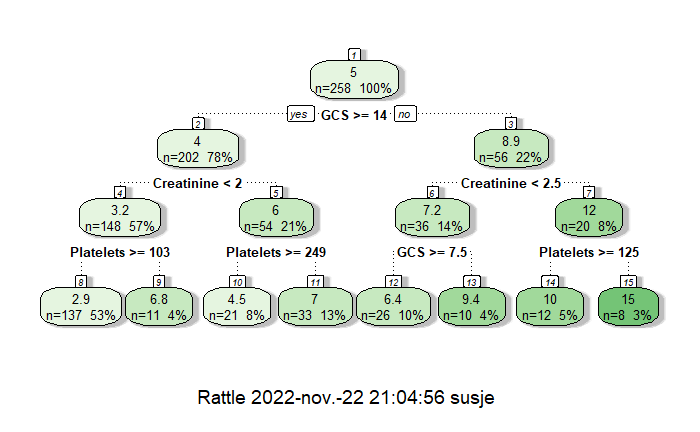

```r
fancyRpartPlot(SOFA_tree_train$finalModel)
```

Utilizamos el modelo para predecir sobre el conjunto de test:

```r
SOFA_tree_predict <- predict(SOFA_tree_train, test_SOFA)
```

Calculamos el rendimiento del algoritmo:

```r
postResample(pred = SOFA_tree_predict, obs = test_SOFA$SOFA.score)
```

```
     RMSE  Rsquared       MAE
2.3693732 0.5779361 1.7401133
```

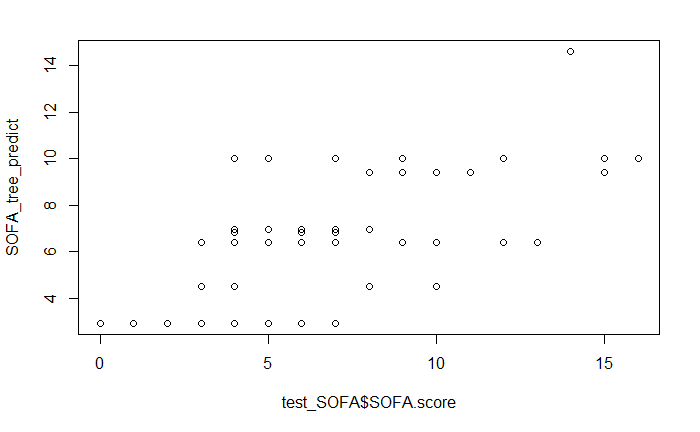

```r
plot(test_SOFA$SOFA.score, SOFA_tree_predict)
```

#### **5. RANDOM FOREST**

En primer lugar, entrenamos nuestro modelo:

```r
set.seed(14)

SOFA_forest_train <- train(SOFA.score ~ .,
                  data = train_SOFA,
                  method = "rf",
                  trControl = trainControl(method = "cv"))
```

```r
SOFA_forest_train
```

```
Random Forest

258 samples
 35 predictor

No pre-processing
Resampling: Cross-Validated (10 fold)
Summary of sample sizes: 233, 230, 232, 233, 233, 232, ...
Resampling results across tuning parameters:

  mtry  RMSE      Rsquared   MAE
   2    2.366412  0.7136602  1.79832
  18    1.831995  0.7342832  1.34531
  35    1.857378  0.7127758  1.35147

RMSE was used to select the optimal model using the smallest value.
The final value used for the model was mtry = 18.
```

Utilizamos el modelo para predecir sobre el conjunto de test:

```r
SOFA_forest_predict <- predict(SOFA_forest_train, test_SOFA)
```

Calculamos el rendimiento del algoritmo:

```r
postResample(pred = SOFA_forest_predict, obs = test_SOFA$SOFA.score)
```

```
     RMSE  Rsquared       MAE
1.8133652 0.7714771 1.2401041
```

#### **6. kNN**

Normalizamos los datos:

```r
normalizar <- function(variable){
  (variable - min(variable)) / (max(variable) - min(variable))
}
```

```r
datos_SOFA_normalizados <- data_SOFA
```

```r
datos_SOFA_normalizados$Age <- normalizar(datos_SOFA_normalizados$Age)  # Normalización: EDAD
datos_SOFA_normalizados$Initial.PCT.value <- normalizar(datos_SOFA_normalizados$Initial.PCT.value)  # Normalización: PCT VALUE
datos_SOFA_normalizados$PaO2 <- normalizar(datos_SOFA_normalizados$PaO2)  # Normalización: PaO2
datos_SOFA_normalizados$FiO2 <- normalizar(datos_SOFA_normalizados$FiO2)  # Normalización: FiO2
datos_SOFA_normalizados$Platelets <- normalizar(datos_SOFA_normalizados$Platelets)  # Normalización: PLATELETS
datos_SOFA_normalizados$Bilirubin <- normalizar(datos_SOFA_normalizados$Bilirubin)  # Normalización: BILIRUBIN
datos_SOFA_normalizados$GCS <- normalizar(datos_SOFA_normalizados$GCS)  # Normalización: GCS
datos_SOFA_normalizados$MAP <- normalizar(datos_SOFA_normalizados$MAP)  # Normalización: MAP
datos_SOFA_normalizados$Creatinine <- normalizar(datos_SOFA_normalizados$Creatinine)  # Normalización: CREATININE
datos_SOFA_normalizados$UOP <- normalizar(datos_SOFA_normalizados$UOP)  # Normalización: UOP
datos_SOFA_normalizados$LOS <- normalizar(datos_SOFA_normalizados$LOS)  # Normalización: LOS
```

```r
train_SOFA_knn <- datos_SOFA_normalizados[indice,]
test_SOFA_knn <- datos_SOFA_normalizados[-indice,]
```

En primer lugar, entrenamos nuestro modelo:

```r
set.seed(14)

SOFA_knn_train <- train(SOFA.score ~ .,
                  data = train_SOFA_knn,
                  method = "knn",
                  trControl = trainControl(method = "cv"),
                  tuneLength = 20)
```

```r
SOFA_knn_train
```

```
k-Nearest Neighbors

258 samples
 35 predictor

No pre-processing
Resampling: Cross-Validated (10 fold)
Summary of sample sizes: 233, 230, 232, 233, 233, 232, ...
Resampling results across tuning parameters:

  k   RMSE      Rsquared   MAE
   5  3.099026  0.2450856  2.233159
   7  3.115959  0.2329594  2.255977
   9  3.102860  0.2392395  2.267814
  11  3.115648  0.2487852  2.281197
  13  3.077095  0.2723332  2.246249
  15  3.115989  0.2506388  2.265630
  17  3.142795  0.2479911  2.281762
  19  3.105885  0.2798125  2.287867
  21  3.108213  0.2807395  2.294893
  23  3.116376  0.2736800  2.305189
  25  3.126229  0.2738453  2.305407
  27  3.137426  0.2704078  2.312247
  29  3.147666  0.2682389  2.316323
  31  3.145691  0.2765970  2.325790
  33  3.150574  0.2753977  2.333945
  35  3.160782  0.2723434  2.337757
  37  3.165715  0.2661577  2.341075
  39  3.169991  0.2618301  2.346281
  41  3.168561  0.2583341  2.353548
  43  3.183378  0.2518437  2.366982

RMSE was used to select the optimal model using the smallest value.
The final value used for the model was k = 13.
```

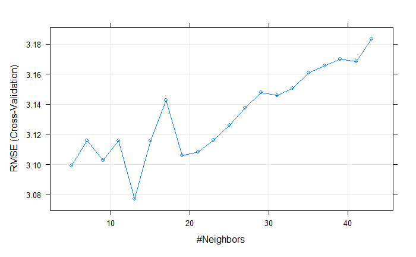

```r
plot(SOFA_knn_train)
```

Utilizamos el modelo para predecir sobre el conjunto de test:

```r
SOFA_knn_predict <- predict(SOFA_knn_train, test_SOFA_knn)
```

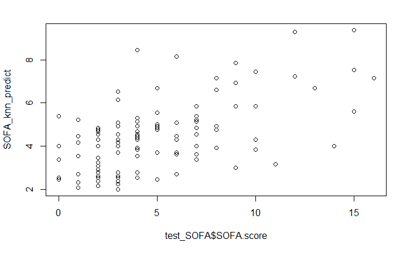

```r
plot(test_SOFA$SOFA.score, SOFA_knn_predict)
```

Calculamos el rendimiento del algoritmo:

```r
postResample(pred = SOFA_knn_predict, obs = test_SOFA$SOFA.score)
```

```
     RMSE  Rsquared       MAE
3.0948047 0.3219186 2.3098694
```

## **7. MÁQUINA DE VECTORES DE SOPORTE LINEAL**

En primer lugar, entrenamos nuestro modelo:

```r
set.seed(14)

sofa_SVM_train <- train(SOFA.score ~ .,
                  data = train_SOFA,
                  method = "svmLinear",
                  trControl = trainControl(method = "cv"),
                  tuneLength = 20)
```

```r
sofa_SVM_train
```

```
Support Vector Machines with Linear Kernel

258 samples
 35 predictor

No pre-processing
Resampling: Cross-Validated (10 fold)
Summary of sample sizes: 233, 230, 232, 233, 233, 232, ...
Resampling results:

  RMSE    Rsquared   MAE
  1.8818  0.7016125  1.394915

Tuning parameter 'C' was held constant at a value of 1
```

Utilizamos el modelo para predecir sobre el conjunto de test:

```r
sofa_SVM_predict <- predict(sofa_SVM_train, test_SOFA)
```

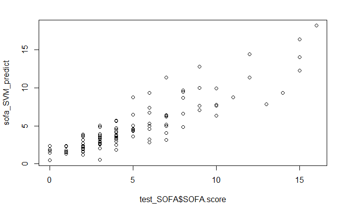

```r
plot(test_SOFA$SOFA.score, sofa_SVM_predict)
```

Calculamos el rendimiento del algoritmo:

```r
postResample(pred = sofa_SVM_predict, obs = test_SOFA$SOFA.score)
```

```
     RMSE  Rsquared       MAE
1.7412747 0.7770363 1.3267195
```

## **8. MÁQUINA DE VECTORES DE SOPORTE KERNEL**

En primer lugar, entrenamos nuestro modelo:

```r
set.seed(14)

sofa_kernel_train <- train(SOFA.score ~ .,
                  data = train_SOFA,
                  method = "svmRadial",
                  trControl = trainControl(method = "cv"),
                  tuneLength = 20)
```

```r
sofa_kernel_train
```

```
Support Vector Machines with Radial Basis Function Kernel

258 samples
 35 predictor

No pre-processing
Resampling: Cross-Validated (10 fold)
Summary of sample sizes: 233, 230, 232, 233, 233, 232, ...
Resampling results across tuning parameters:

  C          RMSE      Rsquared   MAE
       0.25  2.432821  0.5908239  1.732255
       0.50  2.213625  0.6299174  1.575945
       1.00  2.037001  0.6612701  1.456098
       2.00  1.945091  0.6776603  1.419262
       4.00  1.930488  0.6746222  1.416592
       8.00  1.950088  0.6665464  1.443128
      16.00  1.961837  0.6626762  1.460243
      32.00  1.965533  0.6618521  1.465912
      64.00  1.965533  0.6618521  1.465912
     128.00  1.965533  0.6618521  1.465912
     256.00  1.965533  0.6618521  1.465912
     512.00  1.965533  0.6618521  1.465912
    1024.00  1.965533  0.6618521  1.465912
    2048.00  1.965533  0.6618521  1.465912
    4096.00  1.965533  0.6618521  1.465912
    8192.00  1.965533  0.6618521  1.465912
   16384.00  1.965533  0.6618521  1.465912
   32768.00  1.965533  0.6618521  1.465912
   65536.00  1.965533  0.6618521  1.465912
  131072.00  1.965533  0.6618521  1.465912

Tuning parameter 'sigma' was held constant at a value of 0.02133967
RMSE was used to select the optimal model using the smallest value.
The final values used for the model were sigma = 0.02133967 and C = 4.
```

Utilizamos el modelo para predecir sobre el conjunto de test:

```r
sofa_kernel_predict <- predict(sofa_kernel_train, test_SOFA)
```

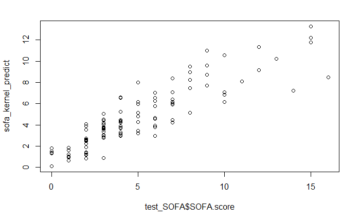

```r
plot(test_SOFA$SOFA.score, sofa_kernel_predict)
```

Calculamos el rendimiento del algoritmo:

```r
postResample(pred = sofa_kernel_predict, obs = test_SOFA$SOFA.score)
```

```
     RMSE  Rsquared       MAE
1.7645754 0.7818092 1.2592353
```